## Project - Cardio Good Fitness

# Objective:

This project is to study the Customers data of the treadmill product(s) of a retail store - **Cardio Good Fitness**.

**Cardio Good Fitness** is a retail store that sells treadmill product(s). It has collected Customer data for each of their users across the various prodcuts. This project is to:

- Study the Customer profile (characteristics of a customer) of the different products
- Perform univariate and multivariate analyses
- Generate a set of insights and recommendations that will help the company in targeting new customers.

Following are the attributes of the Dataset collected for the analysis:

- Product - The model no. of the treadmill
- Age - Age of the customer in no of years
- Gender - Gender of the customer
- Education - Education of the customer in no. of years
- Marital Status - Marital status of the customer
- Usage - Avg. # times the customer wants to use the treadmill every week
- Fitness - Self rated fitness score of the customer (5 - very fit, 1 - very unfit)
- Income - Income of the customer
- Miles- Miles that a customer expects to run

### Importing the necessary packages:

```python
# Importing the Python Libraries to help with reading and manipulating data
import numpy as np
import pandas as pd

# Importing libraries to help with data visualization
import matplotlib.pyplot as plt
import seaborn as sns

# Command to tell Python to actually display the graphs
%matplotlib inline

# let's start by installing plotly
!pip install plotly

# importing plotly
import plotly.express as px
```

```python
# Loading the Cardio Fitness Dataset
df = pd.read_csv('../Dataset/CardioGoodFitness.csv')
```

### Unwrapping the Customer Information:

```python
# Command to understand the total number of data collected
print("- There are " + str(df.shape[0]) + " row samples and " + str(df.shape[1]) + " attributes of the customer information collected in this dataset.")
```

```
- There are 180 row samples and 9 attributes of the customer information collected in this dataset.
```

```python
#Checking the dataypes of the attributes
df.info()
```

```
<class 'pandas.core.frame.DataFrame'>
RangeIndex: 180 entries, 0 to 179
Data columns (total 9 columns):
 #   Column         Non-Null Count  Dtype
---  ------         --------------  -----
 0   Product        180 non-null    object
 1   Age            180 non-null    int64
 2   Gender         180 non-null    object
 3   Education      180 non-null    int64
 4   MaritalStatus  180 non-null    object
 5   Usage          180 non-null    int64
 6   Fitness        180 non-null    int64
 7   Income         180 non-null    int64
 8   Miles          180 non-null    int64
dtypes: int64(6), object(3)
memory usage: 12.8+ KB
```

- *There are 3 Object Types and 6 Integer numbers in the attributes*. The data types of the attributes are appropriate to the values stored in each of the attribute

### Perform the Sanity Check

```python
# Checking for Null values in the dataset
df.isnull().sum()
```

```
Product          0
Age              0
Gender           0
Education        0
MaritalStatus    0
Usage            0
Fitness          0
Income           0
Miles            0
dtype: int64
```

- *There are **no Null** values in the dataset. The data is in good shape to proceed with the next step.*

```python
# Checking for any duplicate values
df.duplicated().sum()
```

```
0
```

- *There are **no duplicate** values in the dataset. We dont have to clean/delete any data for duplicate rows.*

### Describing the Dataset to understand the structure & statistical information

```python
df.describe(include="all").T
```

|  | count | unique | top | freq | mean | std | min | 25% | 50% | 75% | max |
| --- | --- | --- | --- | --- | --- | --- | --- | --- | --- | --- | --- |
| Product | 180 | 3 | TM195 | 80 | NaN | NaN | NaN | NaN | NaN | NaN | NaN |
| Age | 180.0 | NaN | NaN | NaN | 28.788889 | 6.943498 | 18.0 | 24.0 | 26.0 | 33.0 | 50.0 |
| Gender | 180 | 2 | Male | 104 | NaN | NaN | NaN | NaN | NaN | NaN | NaN |
| Education | 180.0 | NaN | NaN | NaN | 15.572222 | 1.617055 | 12.0 | 14.0 | 16.0 | 16.0 | 21.0 |
| MaritalStatus | 180 | 2 | Partnered | 107 | NaN | NaN | NaN | NaN | NaN | NaN | NaN |
| Usage | 180.0 | NaN | NaN | NaN | 3.455556 | 1.084797 | 2.0 | 3.0 | 3.0 | 4.0 | 7.0 |
| Fitness | 180.0 | NaN | NaN | NaN | 3.311111 | 0.958869 | 1.0 | 3.0 | 3.0 | 4.0 | 5.0 |
| Income | 180.0 | NaN | NaN | NaN | 53719.577778 | 16506.684226 | 29562.0 | 44058.75 | 50596.5 | 58668.0 | 104581.0 |
| Miles | 180.0 | NaN | NaN | NaN | 103.194444 | 51.863605 | 21.0 | 66.0 | 94.0 | 114.75 | 360.0 |

**Inferences**:

- Product:
  - *There are 3 unique product models for which the sample data was collected*
  - *TM195 was the top selling Product based on the sample provided and it was reported 80 times*
- Age:
  - *Min age is 18 and max age is 50. Average age is 28 years*
  - *50% of the sampling has an age less than 26*
- Gender:
  - *Sample contains more of Male gender, with around 104 occurences*
- Education:
  - *Min 12 years and max is 21 years of Education. Average is 15 years*
  - *50% of the sampling has an average of 16 years of Education*
- Marital Status:
  - *Mostly partnered status are the maximum population in the samples*
- Other Inferences:
  - *Customers are planning to use the tread mill between 2 hours to max of 7 hours, with an average of 3.5 hours expected*
  - *Customers have rated their fitness from a rating of 1 - 5 with average rating of 3*
  - *Income varies between 29K to 104K with an average of 53K*
  - *Expecting to run between 21 miles to 360 miles in the treadmill*

### Analyzing respective attributes to understand the data pattern

**Analyzing the count and percentage of Categorical attributes using a bar chart**

```python
# Creating a function to display the values of the attributes against the chart
def displayValues(feature):
    ax = sns.countplot(data=df, x=feature);

    plt.rcParams["figure.figsize"] = [7.00, 3.50]
    plt.rcParams["figure.autolayout"] = True

    for p in ax.patches:
       ax.annotate('{:.1f}'.format(p.get_height()), (p.get_x()+0.25, p.get_height()+0.5))

    plt.show()
```

**Analyzing the Product Category**

```
TM195    80
TM498    60
TM798    40
Name: Product, dtype: int64
```

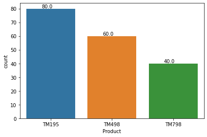

```python
print(df['Product'].value_counts());
displayValues('Product')
```

**Analyzing the Gender Category**

```
Male      104
Female     76
Name: Gender, dtype: int64
```

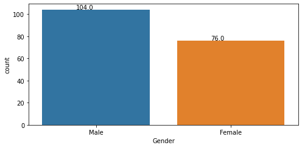

```python
print(df['Gender'].value_counts())
displayValues('Gender')
```

**Analyzing the Marital Status Category**

```
Partnered    107
Single        73
Name: MaritalStatus, dtype: int64
```

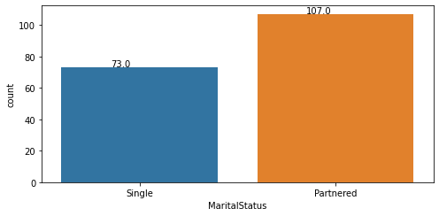

```python
print(df['MaritalStatus'].value_counts())
displayValues('MaritalStatus');
```

**Overall observations of the Categorical attributes**

- *Product TM195 (max of 80 Treadmills) is top selling, followed by TM498 & then TM798*
- *Male customers are the maximum number of users of the products*
- *Customers with Marital status - "Partnered" are the maximun number of users*

**Analyzing the Numerical attributes**

```python
# Creating a common function to draw a Boxplot & a Histogram for each of the analysis
def histogram_boxplot(data, feature, figsize=(12, 7), kde=True, bins=None):
    f2, (ax_box2, ax_hist2) = plt.subplots(
        nrows=2,  # Number of rows of the subplot grid= 2
        sharex=True,  # x-axis will be shared among all subplots
        gridspec_kw={"height_ratios": (0.25, 0.75)},
        figsize=figsize)  # creating the 2 subplots

    sns.boxplot(data=data, x=feature, ax=ax_box2, showmeans=True, color="violet")  # boxplot will be created and a star will indicate the mean value of the column

    if bins:
      sns.histplot(data=data, x=feature, kde=kde, ax=ax_hist2, bins=bins, palette="winter")
    else:
      sns.histplot(data=data, x=feature, kde=kde, ax=ax_hist2)  # For histogram

    ax_hist2.axvline(data[feature].mean(), color="green", linestyle="--")  # Add mean to the histogram

    ax_hist2.axvline(data[feature].median(), color="black", linestyle="-")  # Add median to the histogram
```

**Analyzing the Age of the Customers**

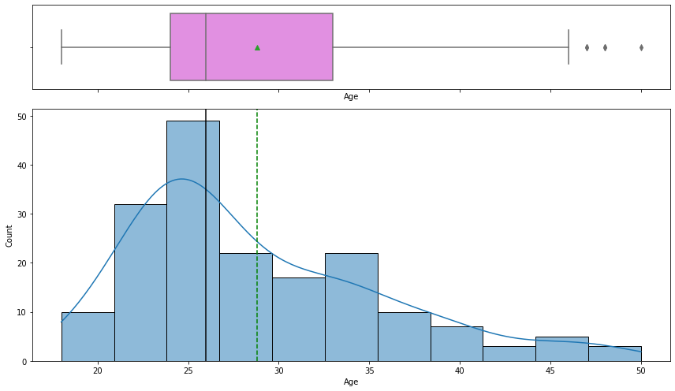

```python
histogram_boxplot(df,'Age')
```

**Analyzing the Education of the Customers**

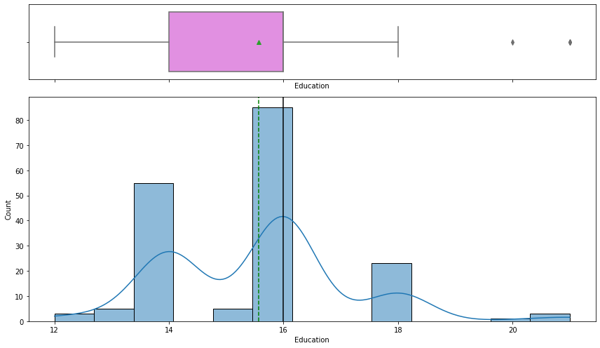

```python
histogram_boxplot(df,'Education')
```

**Analyzing the Usage of the Customers**

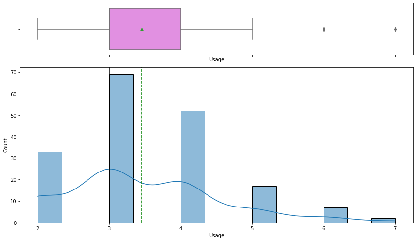

```python
histogram_boxplot(df,'Usage')
```

**Observations:**

- Usage attribute has a **right-skewed** distribution with some outliers towards the higher end*
- The median is at **3 hours** which is same as the 1st (Q1) quartile. Mean is more than the Median

**Analyzing the Fitness of the Customers**

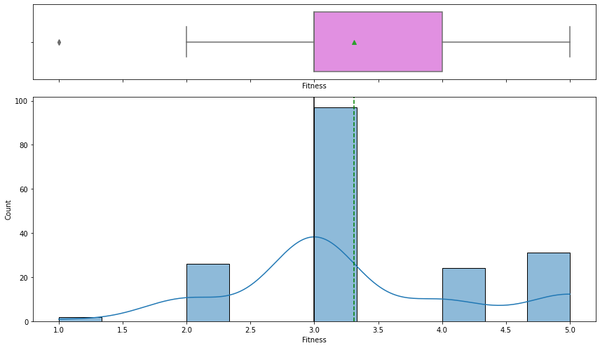

```python
histogram_boxplot(df,'Fitness')
```

**Analyzing the Income of the Customers**

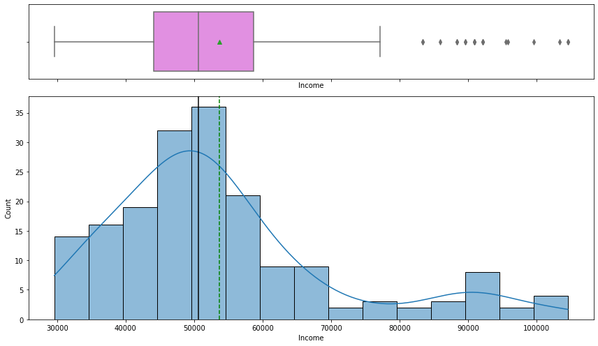

```python
histogram_boxplot(df,'Income')
```

**Observations:**

- Income attribute has a **right-skewed** distribution with more outliers towards the higher end*
- Median is lesser than the Mean

**Analyzing the Miles run by the Customers**

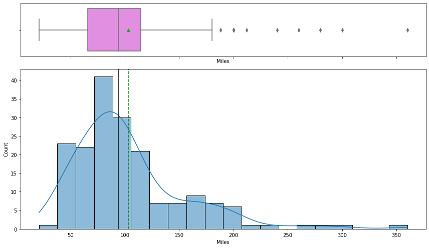

```python
histogram_boxplot(df,'Miles')
```

**Observations:**

- Mile attribute is highly having a **right-skewed** distribution with more outliers towards the higher end*
- It has an average Mean of 103 vs a Median of 94 miles

## Visualise Numerical variables association with each other & its Correlation

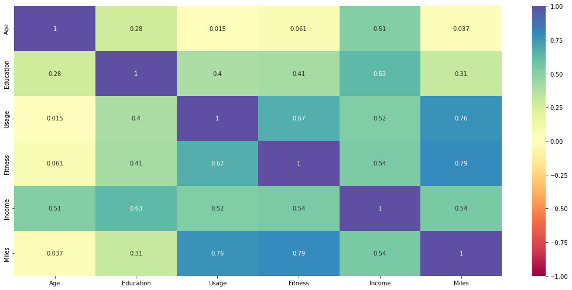

```python
# Plotting Heatmap by creating a 2-D Matrix with correlation plots
correlation = df.corr()
plt.figure(figsize=(15, 7))
sns.heatmap(correlation, vmin = -1, vmax = 1, annot=True, cmap="Spectral");
```

**Observations:**

- *Income has a high positive correlation with Education & Age*
- *Miles run has high positive correlation with Usage & Fitness*
- *Age has a lower correlation with Fitness, Usage and Miles*
- *Fitness has higher correlation with Usage*
- *Education has a postive correlation with Fitness & Usage*

### Analyzing the attributes with high correlation

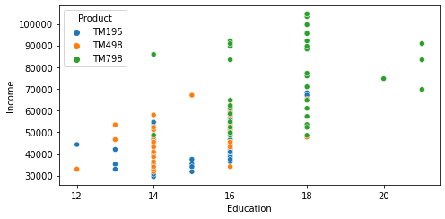

```python
#Analyzing the Education vs Income correlation against the various Products
sns.scatterplot(data=df, x='Education', y='Income', hue="Product");
```

**Observations:**

- *As the Education increases, the Income level is also increasing*
- *TM798 Product users have the highest level of number of years of education*

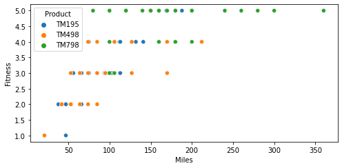

```python
#Analyzing the Miles Run vs Fitness correlation against the various Products
sns.scatterplot(data=df, x='Miles', y='Fitness', hue="Product");
```

**Observations:**

- *As the number of Miles run increases, the Fitness Level is also increasing*
- *TM798 product is having high fitness level when compared with other products*
- *TM798 product seems to provide high fitness levels even with low miles*

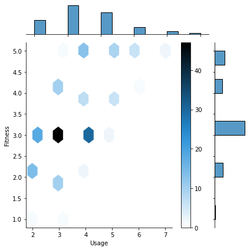

```python
#Analyzing the Usage vs Fitness level correlation
sns.jointplot(data=df, x='Usage', y='Fitness', kind="hex"); #Analyzing Usage vs Fitness
plt.colorbar(); # adds a separate axis indicating the color scale in this plot
```

**Observations:**

- *Most of the users maintain a fitness level of 3 when they use treadmill on an average of 3 times/week*
- *As the usage increase, the Fitness level is also increasing*

### **High Level Product vs Customer Profile comparison :**

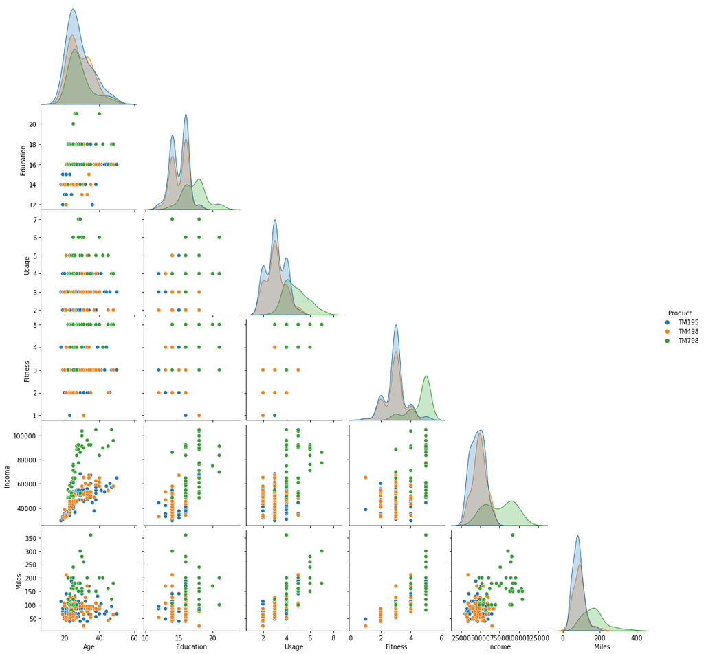

```python
# Plotting pairplot with a hue based on the Product attribute
sns.pairplot(df, diag_kind="kde", corner=True, hue="Product");
```

```python
# Commnad to group the attributes based on Products to compare at a high level
df.groupby("Product")["Age",  "Education",  "Usage", "Fitness", "Income", "Miles"].mean().T
```

| Product | TM195 | TM498 | TM798 |
| --- | --- | --- | --- |
| Age | 28.5500 | 28.900000 | 29.100 |
| Education | 15.0375 | 15.116667 | 17.325 |
| Usage | 3.0875 | 3.066667 | 4.775 |
| Fitness | 2.9625 | 2.900000 | 4.625 |
| Income | 46418.0250 | 48973.650000 | 75441.575 |
| Miles | 82.7875 | 87.933333 | 166.900 |

**Inferences:**

- TM798 treadmill product is used by high Income users with more number of years of Education
- Fitness level & Usage is high for TM798 product when compared with other two products
- Customers using TM798 are planning to run an average of 166 miles which is 100% more than the users planning to run in the other products.
- It also suggests that this product is easy to use and helps keeps high level of fitness
- Both TM195 & TM498 products Customers have almost same level of usage & fitness

### Segregating the Product information into separate Dataframes to detail it further

```python
df_TM195 = df[df["Product"] == "TM195"] # Product TM195
df_TM498 = df[df["Product"] == "TM498"] # Product TM498
df_TM798 = df[df["Product"] == "TM798"] # Product TM798
```

#### *TM195* **Customer Profile :**

Following is the profiling of the **TM195** ThreadMill users.

```python
# Describing the Dataset to understand the structure & statistical information specifically for TM195 users
df_TM195.describe(include="all").T
```

|  | count | unique | top | freq | mean | std | min | 25% | 50% | 75% | max |
| --- | --- | --- | --- | --- | --- | --- | --- | --- | --- | --- | --- |
| Product | 80 | 1 | TM195 | 80 | NaN | NaN | NaN | NaN | NaN | NaN | NaN |
| Age | 80.0 | NaN | NaN | NaN | 28.55 | 7.221452 | 18.0 | 23.0 | 26.0 | 33.0 | 50.0 |
| Gender | 80 | 2 | Male | 40 | NaN | NaN | NaN | NaN | NaN | NaN | NaN |
| Education | 80.0 | NaN | NaN | NaN | 15.0375 | 1.216383 | 12.0 | 14.0 | 16.0 | 16.0 | 18.0 |
| MaritalStatus | 80 | 2 | Partnered | 48 | NaN | NaN | NaN | NaN | NaN | NaN | NaN |
| Usage | 80.0 | NaN | NaN | NaN | 3.0875 | 0.782624 | 2.0 | 3.0 | 3.0 | 4.0 | 5.0 |
| Fitness | 80.0 | NaN | NaN | NaN | 2.9625 | 0.66454 | 1.0 | 3.0 | 3.0 | 3.0 | 5.0 |
| Income | 80.0 | NaN | NaN | NaN | 46418.025 | 9075.78319 | 29562.0 | 38658.0 | 46617.0 | 53439.0 | 68220.0 |
| Miles | 80.0 | NaN | NaN | NaN | 82.7875 | 28.874102 | 38.0 | 66.0 | 85.0 | 94.0 | 188.0 |

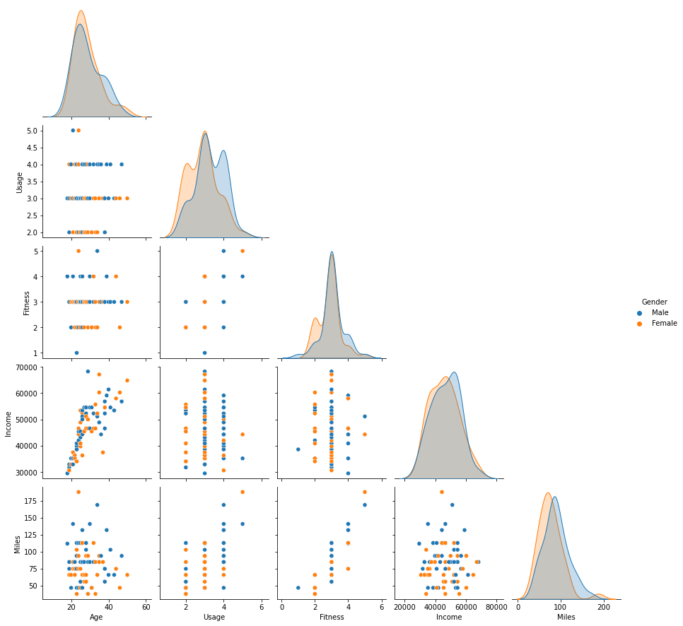

```python
sns.pairplot(data=df_TM195, vars=['Age', 'Usage', 'Fitness', 'Income', 'Miles'], corner=True, hue="Gender");
```

**Based on the trends:**

- Usage & fitness levels are uniformally distributed. With increase in usage, fitness levels are also increasing. But when the age increases, though usage is more, the fitness level seems to be medium
- Male Customers seems to be having higher usage every week than Female users
- As age increases, the run miles seems to decrease

#### *TM498* **Customer Profile :**

Following is the profiling of the **TM498** ThreadMill users.

```python
# Describing the Dataset to understand the structure & statistical information specifically for TM498 users
df_TM498.describe(include="all").T
```

|  | count | unique | top | freq | mean | std | min | 25% | 50% | 75% | max |
| --- | --- | --- | --- | --- | --- | --- | --- | --- | --- | --- | --- |
| Product | 60 | 1 | TM498 | 60 | NaN | NaN | NaN | NaN | NaN | NaN | NaN |
| Age | 60.0 | NaN | NaN | NaN | 28.9 | 6.645248 | 19.0 | 24.0 | 26.0 | 33.25 | 48.0 |
| Gender | 60 | 2 | Male | 31 | NaN | NaN | NaN | NaN | NaN | NaN | NaN |
| Education | 60.0 | NaN | NaN | NaN | 15.116667 | 1.222552 | 12.0 | 14.0 | 16.0 | 16.0 | 18.0 |
| MaritalStatus | 60 | 2 | Partnered | 36 | NaN | NaN | NaN | NaN | NaN | NaN | NaN |
| Usage | 60.0 | NaN | NaN | NaN | 3.066667 | 0.799717 | 2.0 | 3.0 | 3.0 | 3.25 | 5.0 |
| Fitness | 60.0 | NaN | NaN | NaN | 2.9 | 0.62977 | 1.0 | 3.0 | 3.0 | 3.0 | 4.0 |
| Income | 60.0 | NaN | NaN | NaN | 48973.65 | 8653.989388 | 31836.0 | 44911.5 | 49459.5 | 53439.0 | 67083.0 |
| Miles | 60.0 | NaN | NaN | NaN | 87.933333 | 33.263135 | 21.0 | 64.0 | 85.0 | 106.0 | 212.0 |

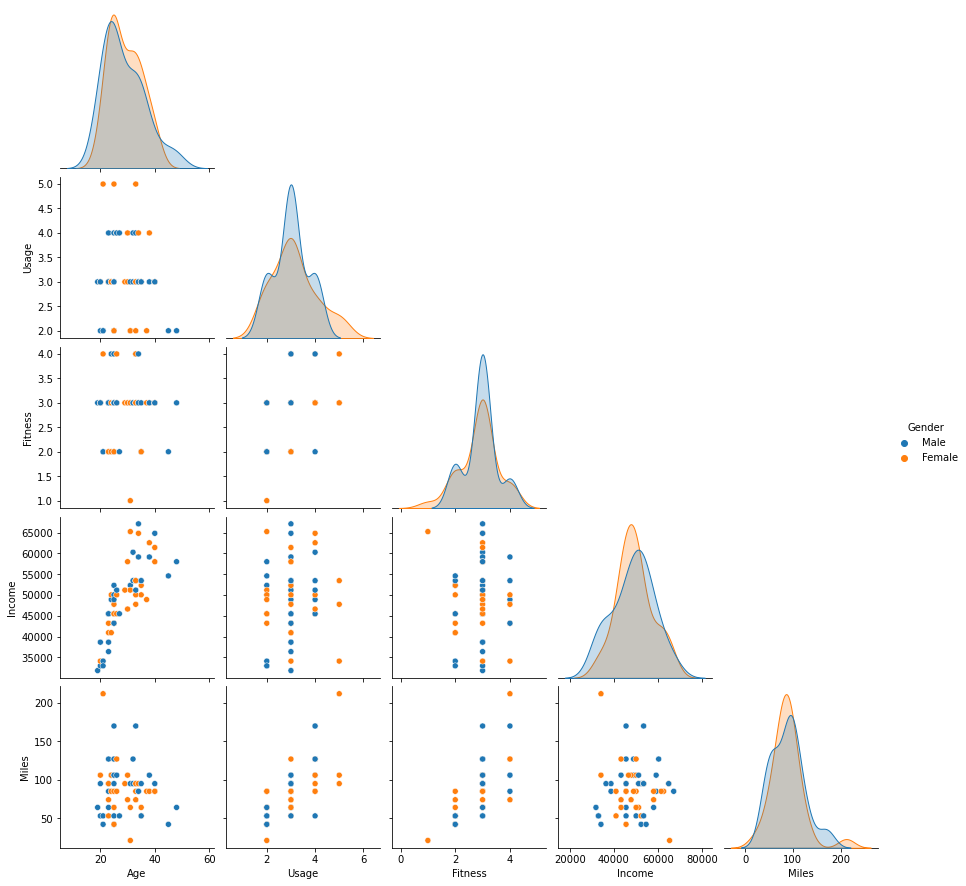

```python
sns.pairplot(data=df_TM498, vars=['Age', 'Usage', 'Fitness', 'Income', 'Miles'], corner=True, hue="Gender");
```

**Inferences:**

- This product has been the second most used treadmill and its liked by users from age 19 to 48 years old
- Male customers are the max users, though its almost same as Female users
- Customers with partners are the highest users of this product as well
- 75% of the users are using the treadmill for 3.25 hours per day and 75% of them maintain a fitness level of 3
- On an average, users run for 88 miles on this treadmill

**Based on the trends:**

- Usage & fitness levels are uniformally distributed. With increase in usage, fitness levels are also increasing. But when the age increases, though usage is more, the fitness level seems to be medium
- Female Customers seems to be having higher usage every week than Male users
- As age increases, the miles covered seems to decrease for Males with less female users using this product

#### *TM798* **Customer Profile :**

Following is the profiling of the **TM798** ThreadMill users.

```python
# Describing the Dataset to understand the structure & statistical information specifically for TM498 users
df_TM798.describe(include="all").T
```

|  | count | unique | top | freq | mean | std | min | 25% | 50% | 75% | max |
| --- | --- | --- | --- | --- | --- | --- | --- | --- | --- | --- | --- |
| Product | 40 | 1 | TM798 | 40 | NaN | NaN | NaN | NaN | NaN | NaN | NaN |
| Age | 40.0 | NaN | NaN | NaN | 29.1 | 6.971738 | 22.0 | 24.75 | 27.0 | 30.25 | 48.0 |
| Gender | 40 | 2 | Male | 33 | NaN | NaN | NaN | NaN | NaN | NaN | NaN |
| Education | 40.0 | NaN | NaN | NaN | 17.325 | 1.639066 | 14.0 | 16.0 | 18.0 | 18.0 | 21.0 |
| MaritalStatus | 40 | 2 | Partnered | 23 | NaN | NaN | NaN | NaN | NaN | NaN | NaN |
| Usage | 40.0 | NaN | NaN | NaN | 4.775 | 0.946993 | 3.0 | 4.0 | 5.0 | 5.0 | 7.0 |
| Fitness | 40.0 | NaN | NaN | NaN | 4.625 | 0.667467 | 3.0 | 4.0 | 5.0 | 5.0 | 5.0 |
| Income | 40.0 | NaN | NaN | NaN | 75441.575 | 18505.83672 | 48556.0 | 58204.75 | 76568.5 | 90886.0 | 104581.0 |
| Miles | 40.0 | NaN | NaN | NaN | 166.9 | 60.066544 | 80.0 | 120.0 | 160.0 | 200.0 | 360.0 |

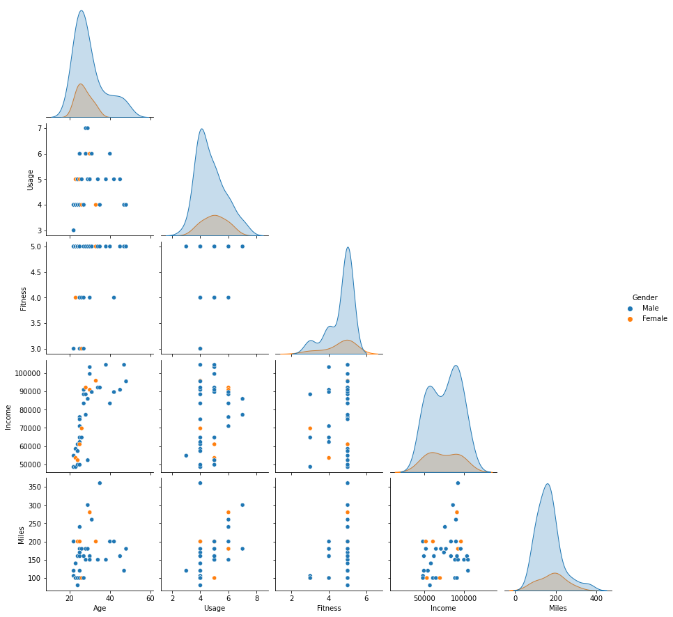

```python
sns.pairplot(data=df_TM798, vars=['Age', 'Usage', 'Fitness', 'Income', 'Miles'], corner=True, hue="Gender");
```

**Based on the trends:**

- Male Customers are the high users of this product
- This tread mill seems to achieve high fitness level even with less usage and less miles run

## Conclusion:

- *There are 3 unique product models for which the sample data was collected*
- *TM195 is the largest sellling product and liked by Customers of all ages. It can be priced economically that fits the budget of all type of users*
- *Most of the users maintain a fitness level of 3 when they use treadmill on an average of 3 times/week*
- *Customers with more years of education seem to be using treadmills more and maintain their fitness at high levels*
- *Age does not seem to be a barrier for fitness and as long as usage and increase in miles run, the fitness level is good*
- *Based on the high fitness level of the TM798, it can be marketed for customers who are fitness experts*
- *TM798 treadmill can be priced higher considering the Fitness advantage and its liked by more educated & high income users*
- *TM498 can be focused towards Female users since they seem to like this product more and have high level of usage*